# Data Manipulation to House Price Advanced Regression train.csv Data

Dhyka

12/9/2021

# Preparation

```r
library(caret)
library(dplyr)
df_house <- read.csv('train.csv')
head(df_house)
```

```
##   Id MSSubClass MSZoning LotFrontage LotArea Street Alley LotShape LandContour
## 1  1         60       RL          65    8450   Pave  <NA>      Reg         Lvl
## 2  2         20       RL          80    9600   Pave  <NA>      Reg         Lvl
## 3  3         60       RL          68   11250   Pave  <NA>      IR1         Lvl
## 4  4         70       RL          60    9550   Pave  <NA>      IR1         Lvl
## 5  5         60       RL          84   14260   Pave  <NA>      IR1         Lvl
## 6  6         50       RL          85   14115   Pave  <NA>      IR1         Lvl
##   Utilities LotConfig LandSlope Neighborhood Condition1 Condition2 BldgType
## 1    AllPub    Inside       Gtl      CollgCr       Norm       Norm     1Fam
## 2    AllPub       FR2       Gtl      Veenker      Feedr       Norm     1Fam
## 3    AllPub    Inside       Gtl      CollgCr       Norm       Norm     1Fam
## 4    AllPub    Corner       Gtl      Crawfor       Norm       Norm     1Fam
## 5    AllPub       FR2       Gtl      NoRidge       Norm       Norm     1Fam
## 6    AllPub    Inside       Gtl      Mitchel       Norm       Norm     1Fam
##   HouseStyle OverallQual OverallCond YearBuilt YearRemodAdd RoofStyle RoofMatl
```

[output cut: 69 more lines]

# Apabila ada data NULL maka perlu diubah menjadi NA menggunakan :

```r
df_house[df_house=='NULL'] <- NA
```

# Namun step ini bisa dilewati karena tidak ada data NULL pada df_house

# — 1. Missing Value —

# Untuk pilihan variable saya memilih ‘LotFrontage’ untuk di-handling

# Untuk melihat baris yang memiliki ‘LotFrontage’ NA menggunakan syntax

```r
filter_baris <- is.na(df_house$LotFrontage)
```

# Isi kolom ‘LotFrontage’ dengan mean (rata-rata)

```r
df_house[is.na(df_house$LotFrontage), 'LotFrontage'] <- mean(df_house$LotFrontage, na.rm = TRUE)
head(df_house$LotFrontage, 50)
```

```
##  [1]  65.00000  80.00000  68.00000  60.00000  84.00000  85.00000  75.00000
##  [8]  70.04996  51.00000  50.00000  70.00000  85.00000  70.04996  91.00000
## [15]  70.04996  51.00000  70.04996  72.00000  66.00000  70.00000 101.00000
## [22]  57.00000  75.00000  44.00000  70.04996 110.00000  60.00000  98.00000
## [29]  47.00000  60.00000  50.00000  70.04996  85.00000  70.00000  60.00000
## [36] 108.00000 112.00000  74.00000  68.00000  65.00000  84.00000 115.00000
## [43]  70.04996  70.04996  70.00000  61.00000  48.00000  84.00000  33.00000
## [50]  66.00000
```

# “na.rm = TRUE” berguna untuk mengabaikan nilai missing dalam perhitungan mean, agar tidak ada nilai 0 saat perhitungan sehingga rata-rata tidak == ‘0’.

# — 2. Normalization / Standarization —

# Pada soal ini saya memilih LotArea menggunakan Normalization

```r
norm_scaler <- preProcess(df_house['LotArea'], method = c('range'))
df_house['LotArea_norm'] <- predict(norm_scaler, df_house['LotArea'] )
head(df_house$LotArea_norm, 50)
```

```
##  [1] 0.03341980 0.03879502 0.04650728 0.03856131 0.06057632 0.05989857
##  [7] 0.04105728 0.04245016 0.02252915 0.02860548 0.04627357 0.04965762
## [13] 0.05453738 0.04371217 0.04496483 0.02252915 0.04646521 0.04436187
## [19] 0.05793545 0.02925986 0.06036598 0.02874103 0.03945874 0.01366706
## [25] 0.03246629 0.06043609 0.02757718 0.04757297 0.07020963 0.02348267
## [31] 0.03365351 0.03385917 0.04556779 0.04324476 0.02810535 0.05664073
## [37] 0.04467971 0.03380308 0.03095188 0.02215523 0.03439202 0.07293931
## [43] 0.03683190 0.03692538 0.03105938 0.02971792 0.05385496 0.04578747
## [49] 0.01475145 0.03011054
```

# Pada step ini, LotArea_norm sudah berubah sekala dari 0~1

# — 3. Data Transformation —

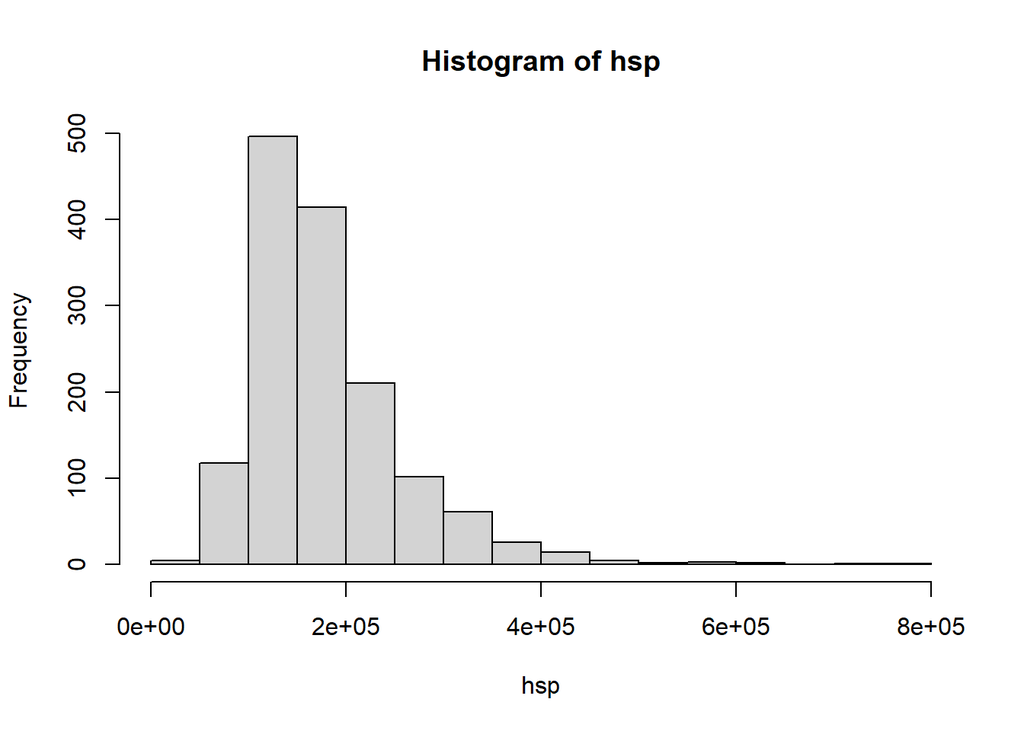

```r
hsp <- df_house$SalePrice
hist(hsp)
```

# Pastikan tidak ada nilai (-) ataupun nilai 0

```r
min(hsp)
```

```
## [1] 34900
```

# Karena tidak ada nilai (-) ataupun nilai 0 , maka bisa langsung menggunakan logarithm transformation

# Apabila ada nilai minimum (-), maka perlu membuat nilai absolut dengan : abs_hsp <- hsp+abs(min(hsp)) + 1

# Apabila ada nilai minimum (0), maka hanya perlu menambah nilai 1 dengan abs_hsp <- hsp+1

```r
hsp_trans <- log(hsp)
```

## Pada step ini, variable ‘SalePrice’ sudah ditransformasi menjadi sebaran mendekati normal, dan disimpan dalam bentuk hsp_trans

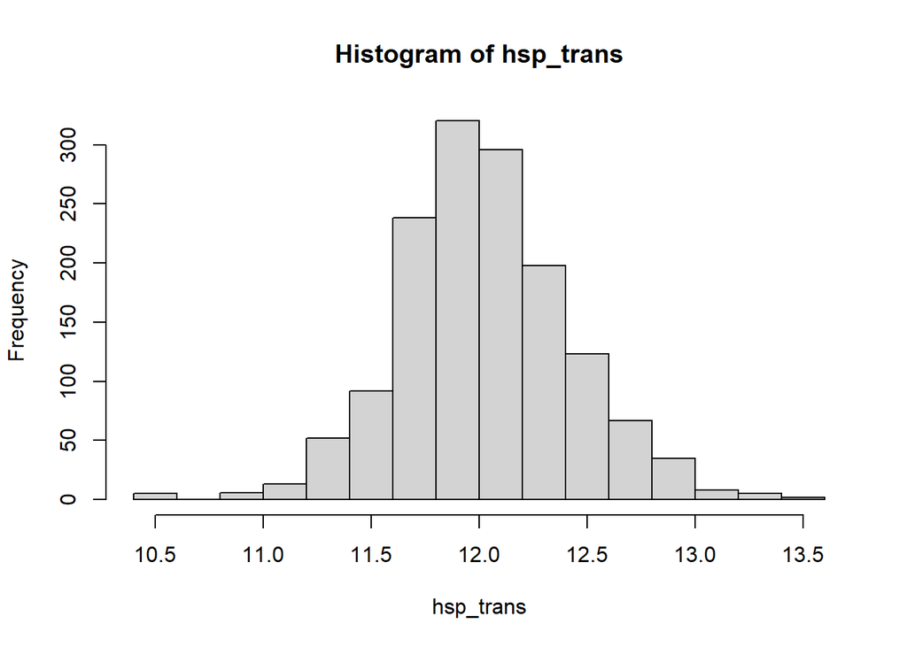

```r
hist(hsp_trans)
```

# — 4. Outlier Handling —

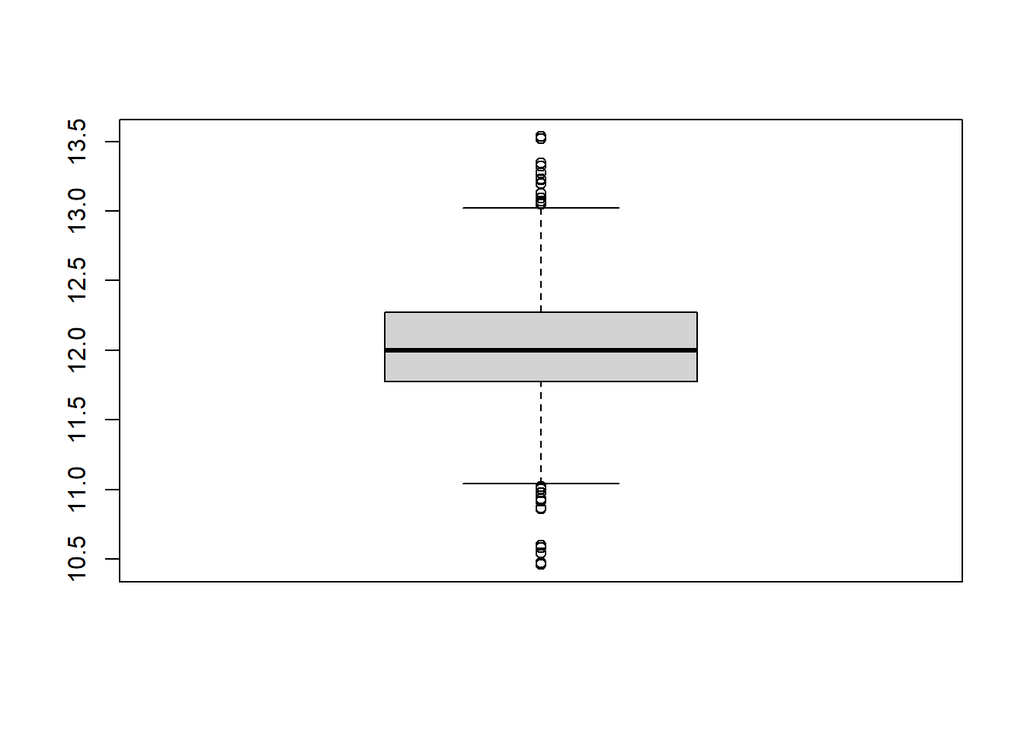

```r
boxplot(hsp_trans)
```

# Dikarenakan final output menggunakan data yang sudah ditransformasi sebelum dibersihkan, saya menggunakan variabel hsp_trans untuk mean, median, lowerbound dan upperbound.

```r
mean_hsp_trans <- mean(hsp_trans)
sd_hsp_trans <- sd(hsp_trans)
alpha_var <- 0.05
lower_bound <- qnorm(alpha_var/2,mean=mean_hsp_trans,sd = sd_hsp_trans)
upper_bound <- qnorm(1-alpha_var/2,mean=mean_hsp_trans,sd = sd_hsp_trans)
```

# Filter df_house dengan lower dan upperbound

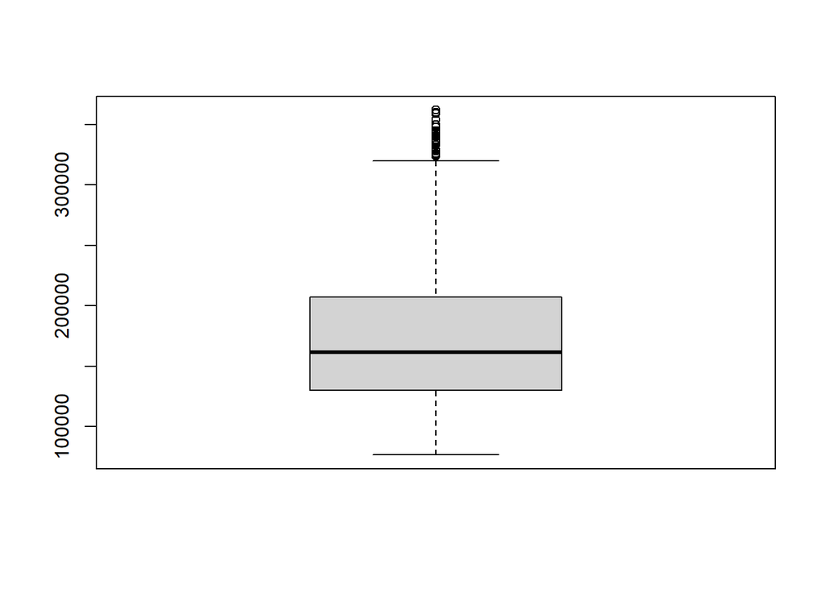

```r
df_house_zd5 <- df_house[hsp_trans > lower_bound & hsp_trans < upper_bound,]
boxplot(df_house_zd5$SalePrice)
```

# Karena masih terdapat outlier, maka dicoba menaikkan alpha variance menjadi 0.15 (15%)

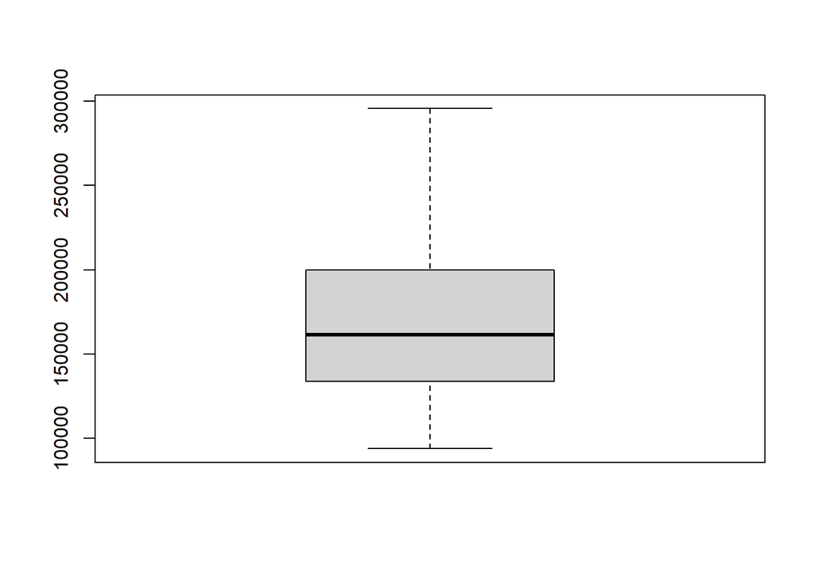

```r
alpha_var <- 0.15
lower_bound <- qnorm(alpha_var/2,mean=mean_hsp_trans,sd = sd_hsp_trans)
upper_bound <- qnorm(1-alpha_var/2,mean=mean_hsp_trans,sd = sd_hsp_trans)
df_house_zd15 <- df_house[hsp_trans > lower_bound & hsp_trans < upper_bound,]
boxplot(df_house_zd15$SalePrice)
```

# Pada step ini, outlier sudah hilang

```r
head(df_house_zd15$SalePrice, 50)
```

```
##  [1] 208500 181500 223500 140000 250000 143000 200000 129900 118000 129500
## [11] 144000 279500 157000 132000 149000 159000 139000 139400 230000 129900
## [21] 154000 256300 134800 207500 149350 179900 165500 277500 145000 153000
## [31] 109000 160000 170000 144000 130250 141000 239686 249700 113000 127000
## [41] 177000 114500 110000 130000 180500 172500 196500 124900 158000 101000
```

# — 5. Data Categorical Handling —

## Untuk soal ini, saya menggunakan kolom ‘Utilities’ untuk variable dengan metode One-Hot Encoding. Pada step ini kita menggunakan dataframe yang sudah terfilter dari outlier pada nomor 1-4

```r
head(df_house_zd15$Utilities, 100)
```

```
##   [1] "AllPub" "AllPub" "AllPub" "AllPub" "AllPub" "AllPub" "AllPub" "AllPub"
##   [9] "AllPub" "AllPub" "AllPub" "AllPub" "AllPub" "AllPub" "AllPub" "AllPub"
##  [17] "AllPub" "AllPub" "AllPub" "AllPub" "AllPub" "AllPub" "AllPub" "AllPub"
##  [25] "AllPub" "AllPub" "AllPub" "AllPub" "AllPub" "AllPub" "AllPub" "AllPub"
##  [33] "AllPub" "AllPub" "AllPub" "AllPub" "AllPub" "AllPub" "AllPub" "AllPub"
##  [41] "AllPub" "AllPub" "AllPub" "AllPub" "AllPub" "AllPub" "AllPub" "AllPub"
##  [49] "AllPub" "AllPub" "AllPub" "AllPub" "AllPub" "AllPub" "AllPub" "AllPub"
##  [57] "AllPub" "AllPub" "AllPub" "AllPub" "AllPub" "AllPub" "AllPub" "AllPub"
##  [65] "AllPub" "AllPub" "AllPub" "AllPub" "AllPub" "AllPub" "AllPub" "AllPub"
##  [73] "AllPub" "AllPub" "AllPub" "AllPub" "AllPub" "AllPub" "AllPub" "AllPub"
##  [81] "AllPub" "AllPub" "AllPub" "AllPub" "AllPub" "AllPub" "AllPub" "AllPub"
##  [89] "AllPub" "AllPub" "AllPub" "AllPub" "AllPub" "AllPub" "AllPub" "AllPub"
##  [97] "AllPub" "AllPub" "AllPub" "AllPub"
```

```r
dummy <- dummyVars("~.",data=df_house_zd15['Utilities'])
dummy_var <- data.frame(predict(dummy, newdata = df_house_zd15['Utilities']))
df_house_enc <- cbind(df_house_zd15,dummy_var)
head((df_house_enc[c("UtilitiesAllPub", "UtilitiesNoSeWa")]), 50)
```

```
##    UtilitiesAllPub UtilitiesNoSeWa
## 1                1               0
## 2                1               0
## 3                1               0
## 4                1               0
## 5                1               0
## 6                1               0
## 8                1               0
## 9                1               0
## 10               1               0
## 11               1               0
## 13               1               0
## 14               1               0
## 15               1               0
## 16               1               0
```

[output cut: 36 more lines]

# — Final Output —

## Variable Missing Value = “LotFrontage”

## Variable Normalization = “LotArea_norm”

## Variable Transformation & Outlier Handling = “SalePrice” menggunakan dataframe terakhir “df_house_enc”

## Variable One Hot Encoding = “UtilitiesAllPub” & “UtilitiesNoSeWa”

```r
df_output = df_house_enc[, c("LotFrontage","LotArea_norm","SalePrice","UtilitiesAllPub","UtilitiesNoSeWa")]
df_output
```

```
##      LotFrontage LotArea_norm SalePrice UtilitiesAllPub UtilitiesNoSeWa
## 1       65.00000  0.033419804    208500               1               0
## 2       80.00000  0.038795017    181500               1               0
## 3       68.00000  0.046507280    223500               1               0
## 4       60.00000  0.038561312    140000               1               0
## 5       84.00000  0.060576316    250000               1               0
## 6       85.00000  0.059898572    143000               1               0
## 8       70.04996  0.042450162    200000               1               0
## 9       51.00000  0.022529155    129900               1               0
## 10      50.00000  0.028605483    118000               1               0
## 11      70.00000  0.046273575    129500               1               0
## 13      70.04996  0.054537381    144000               1               0
## 14      91.00000  0.043712169    279500               1               0
## 15      70.04996  0.044964827    157000               1               0
## 16      51.00000  0.022529155    132000               1               0
```

[output cut: 1233 more lines]